# Risk Factor Analysis

## Outcome Variable

**Outcome Variable:** whz

## Predictor Variables

**Intervention Variable:** exclfeed3

**Adjustment Set:**

- arm
- sex
- brthmon
- W_mage
- meducyrs
- feducyrs
- hhwealth_quart
- hfoodsec
- W_mhtcm
- W_mwtkg
- W_mbmi
- vagbrth
- W_gagebrth
- W_birthwt
- W_birthlen
- W_nrooms
- W_nchldlt5
- month
- W_parity
- impfloor
- impsan
- safeh20
- delta_W_mage
- delta_meducyrs
- delta_feducyrs
- delta_hhwealth_quart
- delta_hfoodsec
- delta_W_mhtcm
- delta_W_mwtkg
- delta_W_mbmi
- delta_vagbrth
- delta_W_gagebrth
- delta_W_birthwt
- delta_W_birthlen
- delta_W_nrooms
- delta_W_nchldlt5
- delta_month
- delta_W_parity
- delta_impfloor
- delta_impsan
- delta_safeh20

## Stratifying Variables

The analysis was stratified on these variable(s):

- agecat
- studyid
- country

## Data Summary

| agecat | studyid | country | exclfeed3 | n_cell | n |
| --- | --- | --- | --- | --- | --- |
| Birth | ki0047075b-MAL-ED | BANGLADESH | 1 | 130 | 202 |
| Birth | ki0047075b-MAL-ED | BANGLADESH | 0 | 72 | 202 |
| Birth | ki0047075b-MAL-ED | BRAZIL | 1 | 11 | 55 |
| Birth | ki0047075b-MAL-ED | BRAZIL | 0 | 44 | 55 |
| Birth | ki0047075b-MAL-ED | INDIA | 1 | 22 | 39 |
| Birth | ki0047075b-MAL-ED | INDIA | 0 | 17 | 39 |
| Birth | ki0047075b-MAL-ED | NEPAL | 1 | 8 | 25 |
| Birth | ki0047075b-MAL-ED | NEPAL | 0 | 17 | 25 |
| Birth | ki0047075b-MAL-ED | PERU | 1 | 47 | 218 |
| Birth | ki0047075b-MAL-ED | PERU | 0 | 171 | 218 |
| Birth | ki0047075b-MAL-ED | SOUTH AFRICA | 1 | 12 | 99 |
| Birth | ki0047075b-MAL-ED | SOUTH AFRICA | 0 | 87 | 99 |
| Birth | ki0047075b-MAL-ED | TANZANIA, UNITED REPUBLIC OF | 1 | 15 | 95 |
| Birth | ki0047075b-MAL-ED | TANZANIA, UNITED REPUBLIC OF | 0 | 80 | 95 |
| Birth | ki1000108-CMC-V-BCS-2002 | INDIA | 1 | 4 | 4 |
| Birth | ki1000108-CMC-V-BCS-2002 | INDIA | 0 | 0 | 4 |
| Birth | ki1000108-IRC | INDIA | 1 | 0 | 9 |
| Birth | ki1000108-IRC | INDIA | 0 | 9 | 9 |
| Birth | ki1000109-EE | PAKISTAN | 1 | 22 | 22 |
| Birth | ki1000109-EE | PAKISTAN | 0 | 0 | 22 |
| Birth | ki1000304b-SAS-CompFeed | INDIA | 1 | 310 | 325 |
| Birth | ki1000304b-SAS-CompFeed | INDIA | 0 | 15 | 325 |
| Birth | ki1017093b-PROVIDE | BANGLADESH | 1 | 381 | 532 |
| Birth | ki1017093b-PROVIDE | BANGLADESH | 0 | 151 | 532 |
| Birth | ki1101329-Keneba | GAMBIA | 1 | 11 | 12 |
| Birth | ki1101329-Keneba | GAMBIA | 0 | 1 | 12 |
| Birth | ki1113344-GMS-Nepal | NEPAL | 1 | 352 | 422 |
| Birth | ki1113344-GMS-Nepal | NEPAL | 0 | 70 | 422 |
| Birth | kiGH5241-JiVitA-3 | BANGLADESH | 1 | 10995 | 12129 |
| Birth | kiGH5241-JiVitA-3 | BANGLADESH | 0 | 1134 | 12129 |

[output cut: 64 more lines]

The following strata were considered:

- agecat: 24 months, studyid: ki0047075b-MAL-ED, country: BANGLADESH
- agecat: 24 months, studyid: ki0047075b-MAL-ED, country: BRAZIL
- agecat: 24 months, studyid: ki0047075b-MAL-ED, country: INDIA
- agecat: 24 months, studyid: ki0047075b-MAL-ED, country: NEPAL
- agecat: 24 months, studyid: ki0047075b-MAL-ED, country: PERU
- agecat: 24 months, studyid: ki0047075b-MAL-ED, country: SOUTH AFRICA
- agecat: 24 months, studyid: ki0047075b-MAL-ED, country: TANZANIA, UNITED REPUBLIC OF
- agecat: 24 months, studyid: ki1000108-CMC-V-BCS-2002, country: INDIA
- agecat: 24 months, studyid: ki1000108-IRC, country: INDIA
- agecat: 24 months, studyid: ki1000109-EE, country: PAKISTAN
- agecat: 24 months, studyid: ki1017093b-PROVIDE, country: BANGLADESH
- agecat: 24 months, studyid: ki1101329-Keneba, country: GAMBIA
- agecat: 24 months, studyid: ki1113344-GMS-Nepal, country: NEPAL
- agecat: 24 months, studyid: kiGH5241-JiVitA-3, country: BANGLADESH
- agecat: 24 months, studyid: kiGH5241-JiVitA-4, country: BANGLADESH
- agecat: 6 months, studyid: ki0047075b-MAL-ED, country: BANGLADESH
- agecat: 6 months, studyid: ki0047075b-MAL-ED, country: BRAZIL
- agecat: 6 months, studyid: ki0047075b-MAL-ED, country: INDIA
- agecat: 6 months, studyid: ki0047075b-MAL-ED, country: NEPAL
- agecat: 6 months, studyid: ki0047075b-MAL-ED, country: PERU
- agecat: 6 months, studyid: ki0047075b-MAL-ED, country: SOUTH AFRICA
- agecat: 6 months, studyid: ki0047075b-MAL-ED, country: TANZANIA, UNITED REPUBLIC OF
- agecat: 6 months, studyid: ki1000108-CMC-V-BCS-2002, country: INDIA
- agecat: 6 months, studyid: ki1000108-IRC, country: INDIA
- agecat: 6 months, studyid: ki1000109-EE, country: PAKISTAN
- agecat: 6 months, studyid: ki1000304b-SAS-CompFeed, country: INDIA
- agecat: 6 months, studyid: ki1017093b-PROVIDE, country: BANGLADESH
- agecat: 6 months, studyid: ki1101329-Keneba, country: GAMBIA
- agecat: 6 months, studyid: ki1113344-GMS-Nepal, country: NEPAL
- agecat: 6 months, studyid: kiGH5241-JiVitA-3, country: BANGLADESH
- agecat: 6 months, studyid: kiGH5241-JiVitA-4, country: BANGLADESH
- agecat: Birth, studyid: ki0047075b-MAL-ED, country: BANGLADESH
- agecat: Birth, studyid: ki0047075b-MAL-ED, country: BRAZIL
- agecat: Birth, studyid: ki0047075b-MAL-ED, country: INDIA
- agecat: Birth, studyid: ki0047075b-MAL-ED, country: NEPAL
- agecat: Birth, studyid: ki0047075b-MAL-ED, country: PERU
- agecat: Birth, studyid: ki0047075b-MAL-ED, country: SOUTH AFRICA
- agecat: Birth, studyid: ki0047075b-MAL-ED, country: TANZANIA, UNITED REPUBLIC OF
- agecat: Birth, studyid: ki1000108-CMC-V-BCS-2002, country: INDIA
- agecat: Birth, studyid: ki1000108-IRC, country: INDIA
- agecat: Birth, studyid: ki1000109-EE, country: PAKISTAN
- agecat: Birth, studyid: ki1000304b-SAS-CompFeed, country: INDIA
- agecat: Birth, studyid: ki1017093b-PROVIDE, country: BANGLADESH
- agecat: Birth, studyid: ki1101329-Keneba, country: GAMBIA
- agecat: Birth, studyid: ki1113344-GMS-Nepal, country: NEPAL
- agecat: Birth, studyid: kiGH5241-JiVitA-3, country: BANGLADESH
- agecat: Birth, studyid: kiGH5241-JiVitA-4, country: BANGLADESH

### Dropped Strata

Some strata were dropped due to rare outcomes:

- agecat: Birth, studyid: ki1000108-CMC-V-BCS-2002, country: INDIA
- agecat: Birth, studyid: ki1000108-IRC, country: INDIA
- agecat: Birth, studyid: ki1000109-EE, country: PAKISTAN
- agecat: Birth, studyid: ki1101329-Keneba, country: GAMBIA
- agecat: 6 months, studyid: ki1000108-CMC-V-BCS-2002, country: INDIA
- agecat: 6 months, studyid: ki1000108-IRC, country: INDIA
- agecat: 6 months, studyid: ki1000109-EE, country: PAKISTAN
- agecat: 24 months, studyid: ki1000108-CMC-V-BCS-2002, country: INDIA
- agecat: 24 months, studyid: ki1000108-IRC, country: INDIA
- agecat: 24 months, studyid: ki1000109-EE, country: PAKISTAN

## Methods Detail

We’re interested in the causal parameters $E[Y_a]$ for all values of $a \in \mathcal{A}$. These parameters represent the mean outcome if, possibly contrary to fact, we intervened to set all units to have $A=a$. Under the randomization and positivity assumptions, these are identified by the statistical parameters $\psi_a=E_W[E_{Y|A,W}(Y|A=a,W)]$. In addition, we’re interested in the mean of $Y$, $E[Y]$ under no intervention (the observed mean). We will estimate these parameters by using SuperLearner to fit the relevant likelihood factors – $E_{Y|A,W}(Y|A=a,W)$ and $p(A=a|W)$, and then updating our likelihood fit using a joint TMLE.

For unadjusted analyses ($W=\{\}$), initial likelihoods were estimated using Lrnr_glm to estimate the simple $E(Y|A)$ and Lrnr_mean to estimate $p(A)$. For adjusted analyses, a small library containing Lrnr_glmnet, Lrnr_xgboost, and Lrnr_mean was used.

Having estimated these parameters, we will then use the delta method to estimate relative risks and attributable risks relative to a prespecified baseline level of $A$.

# Results Detail

## Results Plots

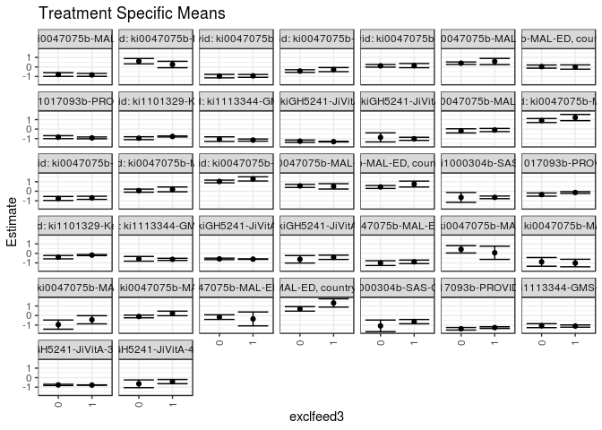

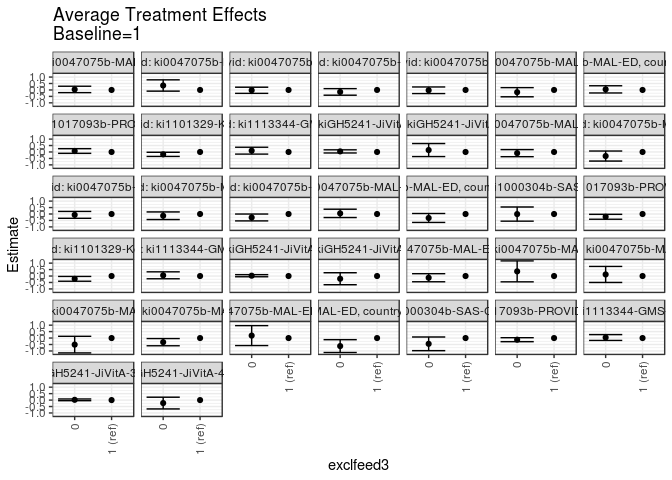

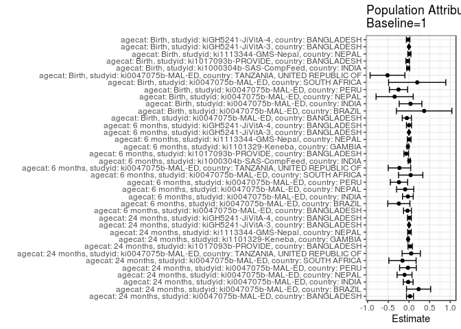

## Results Table

### Parameter: TSM

| agecat | studyid | country | intervention_level | baseline_level | estimate | ci_lower | ci_upper |
| --- | --- | --- | --- | --- | --- | --- | --- |
| Birth | ki0047075b-MAL-ED | BANGLADESH | 1 | NA | -0.8906860 | -1.0754562 | -0.7059158 |
| Birth | ki0047075b-MAL-ED | BANGLADESH | 0 | NA | -1.0226580 | -1.2738449 | -0.7714711 |
| Birth | ki0047075b-MAL-ED | BRAZIL | 1 | NA | 0.0624707 | -0.6320786 | 0.7570201 |
| Birth | ki0047075b-MAL-ED | BRAZIL | 0 | NA | 0.4238733 | 0.0400660 | 0.8076805 |
| Birth | ki0047075b-MAL-ED | INDIA | 1 | NA | -1.0175896 | -1.4137359 | -0.6214433 |
| Birth | ki0047075b-MAL-ED | INDIA | 0 | NA | -0.8949113 | -1.3532602 | -0.4365623 |
| Birth | ki0047075b-MAL-ED | NEPAL | 1 | NA | -0.4487500 | -0.8783289 | -0.0191711 |
| Birth | ki0047075b-MAL-ED | NEPAL | 0 | NA | -0.9570588 | -1.4394884 | -0.4746293 |
| Birth | ki0047075b-MAL-ED | PERU | 1 | NA | 0.2185769 | -0.0214174 | 0.4585711 |
| Birth | ki0047075b-MAL-ED | PERU | 0 | NA | -0.1008270 | -0.2436393 | 0.0419852 |
| Birth | ki0047075b-MAL-ED | SOUTH AFRICA | 1 | NA | -0.3597300 | -1.0902600 | 0.3708000 |
| Birth | ki0047075b-MAL-ED | SOUTH AFRICA | 0 | NA | -0.1684631 | -0.4109027 | 0.0739765 |
| Birth | ki0047075b-MAL-ED | TANZANIA, UNITED REPUBLIC OF | 1 | NA | 1.3177658 | 0.8814013 | 1.7541303 |
| Birth | ki0047075b-MAL-ED | TANZANIA, UNITED REPUBLIC OF | 0 | NA | 0.6954843 | 0.4620697 | 0.9288989 |
| Birth | ki1000304b-SAS-CompFeed | INDIA | 1 | NA | -0.6419787 | -0.8661092 | -0.4178481 |
| Birth | ki1000304b-SAS-CompFeed | INDIA | 0 | NA | -1.0901282 | -1.7027393 | -0.4775170 |
| Birth | ki1017093b-PROVIDE | BANGLADESH | 1 | NA | -1.2691896 | -1.3566064 | -1.1817728 |
| Birth | ki1017093b-PROVIDE | BANGLADESH | 0 | NA | -1.3954101 | -1.5307437 | -1.2600765 |
| Birth | ki1113344-GMS-Nepal | NEPAL | 1 | NA | -1.1106934 | -1.2290199 | -0.9923669 |
| Birth | ki1113344-GMS-Nepal | NEPAL | 0 | NA | -1.0684445 | -1.2756815 | -0.8612075 |
| Birth | kiGH5241-JiVitA-3 | BANGLADESH | 1 | NA | -0.7840131 | -0.8064950 | -0.7615313 |
| Birth | kiGH5241-JiVitA-3 | BANGLADESH | 0 | NA | -0.7638414 | -0.8274603 | -0.7002224 |
| Birth | kiGH5241-JiVitA-4 | BANGLADESH | 1 | NA | -0.4156180 | -0.6383645 | -0.1928714 |
| Birth | kiGH5241-JiVitA-4 | BANGLADESH | 0 | NA | -0.6475000 | -1.0569566 | -0.2380434 |
| 6 months | ki0047075b-MAL-ED | BANGLADESH | 1 | NA | -0.0959780 | -0.2620715 | 0.0701155 |
| 6 months | ki0047075b-MAL-ED | BANGLADESH | 0 | NA | -0.1862601 | -0.4044448 | 0.0319247 |
| 6 months | ki0047075b-MAL-ED | BRAZIL | 1 | NA | 1.2165496 | 0.8896861 | 1.5434130 |
| 6 months | ki0047075b-MAL-ED | BRAZIL | 0 | NA | 0.9013338 | 0.6910551 | 1.1116125 |
| 6 months | ki0047075b-MAL-ED | INDIA | 1 | NA | -0.6938755 | -0.8573340 | -0.5304170 |
| 6 months | ki0047075b-MAL-ED | INDIA | 0 | NA | -0.7611058 | -0.9693215 | -0.5528900 |
| 6 months | ki0047075b-MAL-ED | NEPAL | 1 | NA | 0.1954780 | -0.0561463 | 0.4471023 |
| 6 months | ki0047075b-MAL-ED | NEPAL | 0 | NA | 0.0616613 | -0.0996369 | 0.2229594 |
| 6 months | ki0047075b-MAL-ED | PERU | 1 | NA | 1.2960569 | 1.0761509 | 1.5159629 |
| 6 months | ki0047075b-MAL-ED | PERU | 0 | NA | 1.0275639 | 0.8818204 | 1.1733074 |
| 6 months | ki0047075b-MAL-ED | SOUTH AFRICA | 1 | NA | 0.5134841 | 0.2339560 | 0.7930121 |
| 6 months | ki0047075b-MAL-ED | SOUTH AFRICA | 0 | NA | 0.5631127 | 0.3998822 | 0.7263432 |
| 6 months | ki0047075b-MAL-ED | TANZANIA, UNITED REPUBLIC OF | 1 | NA | 0.7550737 | 0.4466899 | 1.0634574 |
| 6 months | ki0047075b-MAL-ED | TANZANIA, UNITED REPUBLIC OF | 0 | NA | 0.4474624 | 0.2934031 | 0.6015217 |
| 6 months | ki1000304b-SAS-CompFeed | INDIA | 1 | NA | -0.6438016 | -0.7819173 | -0.5056859 |
| 6 months | ki1000304b-SAS-CompFeed | INDIA | 0 | NA | -0.6500492 | -1.1672739 | -0.1328245 |
| 6 months | ki1017093b-PROVIDE | BANGLADESH | 1 | NA | -0.1351001 | -0.2295431 | -0.0406572 |
| 6 months | ki1017093b-PROVIDE | BANGLADESH | 0 | NA | -0.3503952 | -0.5158938 | -0.1848965 |
| 6 months | ki1101329-Keneba | GAMBIA | 1 | NA | -0.1816293 | -0.2399912 | -0.1232673 |
| 6 months | ki1101329-Keneba | GAMBIA | 0 | NA | -0.3988791 | -0.5754161 | -0.2223421 |
| 6 months | ki1113344-GMS-Nepal | NEPAL | 1 | NA | -0.6266025 | -0.7365379 | -0.5166671 |
| 6 months | ki1113344-GMS-Nepal | NEPAL | 0 | NA | -0.5703035 | -0.8174778 | -0.3231291 |
| 6 months | kiGH5241-JiVitA-3 | BANGLADESH | 1 | NA | -0.6057195 | -0.6312583 | -0.5801807 |
| 6 months | kiGH5241-JiVitA-3 | BANGLADESH | 0 | NA | -0.5807262 | -0.6579620 | -0.5034903 |
| 6 months | kiGH5241-JiVitA-4 | BANGLADESH | 1 | NA | -0.4132713 | -0.6418409 | -0.1847017 |
| 6 months | kiGH5241-JiVitA-4 | BANGLADESH | 0 | NA | -0.6225930 | -1.0153135 | -0.2298725 |
| 24 months | ki0047075b-MAL-ED | BANGLADESH | 1 | NA | -0.8347300 | -0.9910815 | -0.6783786 |
| 24 months | ki0047075b-MAL-ED | BANGLADESH | 0 | NA | -0.7933613 | -0.9857928 | -0.6009298 |
| 24 months | ki0047075b-MAL-ED | BRAZIL | 1 | NA | 0.2600484 | -0.0790106 | 0.5991074 |
| 24 months | ki0047075b-MAL-ED | BRAZIL | 0 | NA | 0.6066239 | 0.3244886 | 0.8887592 |
| 24 months | ki0047075b-MAL-ED | INDIA | 1 | NA | -0.9355250 | -1.0872521 | -0.7837979 |
| 24 months | ki0047075b-MAL-ED | INDIA | 0 | NA | -0.9607630 | -1.1455370 | -0.7759890 |
| 24 months | ki0047075b-MAL-ED | NEPAL | 1 | NA | -0.2749930 | -0.4903082 | -0.0596778 |
| 24 months | ki0047075b-MAL-ED | NEPAL | 0 | NA | -0.4270090 | -0.5658138 | -0.2882042 |
| 24 months | ki0047075b-MAL-ED | PERU | 1 | NA | 0.1430382 | -0.0772641 | 0.3633405 |
| 24 months | ki0047075b-MAL-ED | PERU | 0 | NA | 0.1199302 | -0.0180113 | 0.2578717 |
| 24 months | ki0047075b-MAL-ED | SOUTH AFRICA | 1 | NA | 0.5737720 | 0.2463839 | 0.9011601 |
| 24 months | ki0047075b-MAL-ED | SOUTH AFRICA | 0 | NA | 0.3979289 | 0.2678602 | 0.5279976 |
| 24 months | ki0047075b-MAL-ED | TANZANIA, UNITED REPUBLIC OF | 1 | NA | -0.0075342 | -0.2333464 | 0.2182779 |
| 24 months | ki0047075b-MAL-ED | TANZANIA, UNITED REPUBLIC OF | 0 | NA | 0.0394791 | -0.1236519 | 0.2026101 |
| 24 months | ki1017093b-PROVIDE | BANGLADESH | 1 | NA | -0.9234786 | -1.0199054 | -0.8270519 |
| 24 months | ki1017093b-PROVIDE | BANGLADESH | 0 | NA | -0.8479577 | -1.0031522 | -0.6927633 |
| 24 months | ki1101329-Keneba | GAMBIA | 1 | NA | -0.7743217 | -0.8285555 | -0.7200878 |
| 24 months | ki1101329-Keneba | GAMBIA | 0 | NA | -0.9580357 | -1.1107611 | -0.8053104 |
| 24 months | ki1113344-GMS-Nepal | NEPAL | 1 | NA | -1.1531163 | -1.2658831 | -1.0403496 |
| 24 months | ki1113344-GMS-Nepal | NEPAL | 0 | NA | -1.0517605 | -1.2919473 | -0.8115736 |
| 24 months | kiGH5241-JiVitA-3 | BANGLADESH | 1 | NA | -1.3163068 | -1.3483388 | -1.2842748 |
| 24 months | kiGH5241-JiVitA-3 | BANGLADESH | 0 | NA | -1.2708720 | -1.3903300 | -1.1514140 |
| 24 months | kiGH5241-JiVitA-4 | BANGLADESH | 1 | NA | -1.0218446 | -1.1843359 | -0.8593532 |
| 24 months | kiGH5241-JiVitA-4 | BANGLADESH | 0 | NA | -0.8727098 | -1.3505836 | -0.3948360 |

### Parameter: E(Y)

| agecat | studyid | country | intervention_level | baseline_level | estimate | ci_lower | ci_upper |
| --- | --- | --- | --- | --- | --- | --- | --- |
| Birth | ki0047075b-MAL-ED | BANGLADESH | NA | NA | -0.9404455 | -1.0889530 | -0.7919381 |
| Birth | ki0047075b-MAL-ED | BRAZIL | NA | NA | 0.4316364 | 0.0969688 | 0.7663039 |
| Birth | ki0047075b-MAL-ED | INDIA | NA | NA | -0.9779487 | -1.2664810 | -0.6894164 |
| Birth | ki0047075b-MAL-ED | NEPAL | NA | NA | -0.7944000 | -1.1625222 | -0.4262778 |
| Birth | ki0047075b-MAL-ED | PERU | NA | NA | -0.0335321 | -0.1564905 | 0.0894263 |
| Birth | ki0047075b-MAL-ED | SOUTH AFRICA | NA | NA | -0.1588889 | -0.3845288 | 0.0667510 |
| Birth | ki0047075b-MAL-ED | TANZANIA, UNITED REPUBLIC OF | NA | NA | 0.7996842 | 0.5874808 | 1.0118876 |
| Birth | ki1000304b-SAS-CompFeed | INDIA | NA | NA | -0.6596308 | -0.9005716 | -0.4186900 |
| Birth | ki1017093b-PROVIDE | BANGLADESH | NA | NA | -1.2984586 | -1.3752758 | -1.2216415 |
| Birth | ki1113344-GMS-Nepal | NEPAL | NA | NA | -1.0991706 | -1.2073693 | -0.9909719 |
| Birth | kiGH5241-JiVitA-3 | BANGLADESH | NA | NA | -0.7822228 | -0.8038489 | -0.7605966 |
| Birth | kiGH5241-JiVitA-4 | BANGLADESH | NA | NA | -0.4347423 | -0.6441144 | -0.2253701 |
| 6 months | ki0047075b-MAL-ED | BANGLADESH | NA | NA | -0.1312375 | -0.2633777 | 0.0009027 |
| 6 months | ki0047075b-MAL-ED | BRAZIL | NA | NA | 0.9730392 | 0.7966084 | 1.1494700 |
| 6 months | ki0047075b-MAL-ED | INDIA | NA | NA | -0.7190952 | -0.8496984 | -0.5884921 |
| 6 months | ki0047075b-MAL-ED | NEPAL | NA | NA | 0.1047871 | -0.0305193 | 0.2400934 |
| 6 months | ki0047075b-MAL-ED | PERU | NA | NA | 1.0554753 | 0.9329598 | 1.1779909 |
| 6 months | ki0047075b-MAL-ED | SOUTH AFRICA | NA | NA | 0.5569945 | 0.4061636 | 0.7078255 |
| 6 months | ki0047075b-MAL-ED | TANZANIA, UNITED REPUBLIC OF | NA | NA | 0.5257626 | 0.3871543 | 0.6643709 |
| 6 months | ki1000304b-SAS-CompFeed | INDIA | NA | NA | -0.6348861 | -0.7630511 | -0.5067211 |
| 6 months | ki1017093b-PROVIDE | BANGLADESH | NA | NA | -0.1990907 | -0.2817968 | -0.1163845 |
| 6 months | ki1101329-Keneba | GAMBIA | NA | NA | -0.2057183 | -0.2614359 | -0.1500006 |
| 6 months | ki1113344-GMS-Nepal | NEPAL | NA | NA | -0.6198791 | -0.7206518 | -0.5191063 |
| 6 months | kiGH5241-JiVitA-3 | BANGLADESH | NA | NA | -0.6040726 | -0.6286341 | -0.5795110 |
| 6 months | kiGH5241-JiVitA-4 | BANGLADESH | NA | NA | -0.4110227 | -0.6122701 | -0.2097753 |
| 24 months | ki0047075b-MAL-ED | BANGLADESH | NA | NA | -0.8086098 | -0.9307952 | -0.6864243 |
| 24 months | ki0047075b-MAL-ED | BRAZIL | NA | NA | 0.4943421 | 0.2716679 | 0.7170163 |
| 24 months | ki0047075b-MAL-ED | INDIA | NA | NA | -0.9524010 | -1.0710590 | -0.8337430 |
| 24 months | ki0047075b-MAL-ED | NEPAL | NA | NA | -0.3806364 | -0.4971717 | -0.2641010 |
| 24 months | ki0047075b-MAL-ED | PERU | NA | NA | 0.1199242 | 0.0008627 | 0.2389858 |
| 24 months | ki0047075b-MAL-ED | SOUTH AFRICA | NA | NA | 0.4181579 | 0.2964894 | 0.5398263 |
| 24 months | ki0047075b-MAL-ED | TANZANIA, UNITED REPUBLIC OF | NA | NA | 0.0485870 | -0.0868148 | 0.1839888 |
| 24 months | ki1017093b-PROVIDE | BANGLADESH | NA | NA | -0.8928670 | -0.9755153 | -0.8102187 |
| 24 months | ki1101329-Keneba | GAMBIA | NA | NA | -0.7930925 | -0.8442611 | -0.7419240 |
| 24 months | ki1113344-GMS-Nepal | NEPAL | NA | NA | -1.1396441 | -1.2416403 | -1.0376479 |
| 24 months | kiGH5241-JiVitA-3 | BANGLADESH | NA | NA | -1.3119979 | -1.3435475 | -1.2804484 |
| 24 months | kiGH5241-JiVitA-4 | BANGLADESH | NA | NA | -1.0096000 | -1.1619164 | -0.8572836 |

### Parameter: ATE

| agecat | studyid | country | intervention_level | baseline_level | estimate | ci_lower | ci_upper |
| --- | --- | --- | --- | --- | --- | --- | --- |
| Birth | ki0047075b-MAL-ED | BANGLADESH | 1 | 1 | 0.0000000 | 0.0000000 | 0.0000000 |
| Birth | ki0047075b-MAL-ED | BANGLADESH | 0 | 1 | -0.1319720 | -0.4438800 | 0.1799360 |
| Birth | ki0047075b-MAL-ED | BRAZIL | 1 | 1 | 0.0000000 | 0.0000000 | 0.0000000 |
| Birth | ki0047075b-MAL-ED | BRAZIL | 0 | 1 | 0.3614025 | -0.4517873 | 1.1745924 |
| Birth | ki0047075b-MAL-ED | INDIA | 1 | 1 | 0.0000000 | 0.0000000 | 0.0000000 |
| Birth | ki0047075b-MAL-ED | INDIA | 0 | 1 | 0.1226783 | -0.4992129 | 0.7445696 |
| Birth | ki0047075b-MAL-ED | NEPAL | 1 | 1 | 0.0000000 | 0.0000000 | 0.0000000 |
| Birth | ki0047075b-MAL-ED | NEPAL | 0 | 1 | -0.5083088 | -1.1542781 | 0.1376604 |
| Birth | ki0047075b-MAL-ED | PERU | 1 | 1 | 0.0000000 | 0.0000000 | 0.0000000 |
| Birth | ki0047075b-MAL-ED | PERU | 0 | 1 | -0.3194039 | -0.5989794 | -0.0398285 |
| Birth | ki0047075b-MAL-ED | SOUTH AFRICA | 1 | 1 | 0.0000000 | 0.0000000 | 0.0000000 |
| Birth | ki0047075b-MAL-ED | SOUTH AFRICA | 0 | 1 | 0.1912669 | -0.5823266 | 0.9648603 |
| Birth | ki0047075b-MAL-ED | TANZANIA, UNITED REPUBLIC OF | 1 | 1 | 0.0000000 | 0.0000000 | 0.0000000 |
| Birth | ki0047075b-MAL-ED | TANZANIA, UNITED REPUBLIC OF | 0 | 1 | -0.6222815 | -1.1199362 | -0.1246268 |
| Birth | ki1000304b-SAS-CompFeed | INDIA | 1 | 1 | 0.0000000 | 0.0000000 | 0.0000000 |
| Birth | ki1000304b-SAS-CompFeed | INDIA | 0 | 1 | -0.4481495 | -0.9783682 | 0.0820692 |
| Birth | ki1017093b-PROVIDE | BANGLADESH | 1 | 1 | 0.0000000 | 0.0000000 | 0.0000000 |
| Birth | ki1017093b-PROVIDE | BANGLADESH | 0 | 1 | -0.1262205 | -0.2797745 | 0.0273336 |
| Birth | ki1113344-GMS-Nepal | NEPAL | 1 | 1 | 0.0000000 | 0.0000000 | 0.0000000 |
| Birth | ki1113344-GMS-Nepal | NEPAL | 0 | 1 | 0.0422489 | -0.1839276 | 0.2684253 |
| Birth | kiGH5241-JiVitA-3 | BANGLADESH | 1 | 1 | 0.0000000 | 0.0000000 | 0.0000000 |
| Birth | kiGH5241-JiVitA-3 | BANGLADESH | 0 | 1 | 0.0201718 | -0.0457495 | 0.0860930 |
| Birth | kiGH5241-JiVitA-4 | BANGLADESH | 1 | 1 | 0.0000000 | 0.0000000 | 0.0000000 |
| Birth | kiGH5241-JiVitA-4 | BANGLADESH | 0 | 1 | -0.2318820 | -0.6871466 | 0.2233826 |
| 6 months | ki0047075b-MAL-ED | BANGLADESH | 1 | 1 | 0.0000000 | 0.0000000 | 0.0000000 |
| 6 months | ki0047075b-MAL-ED | BANGLADESH | 0 | 1 | -0.0902820 | -0.3648887 | 0.1843247 |
| 6 months | ki0047075b-MAL-ED | BRAZIL | 1 | 1 | 0.0000000 | 0.0000000 | 0.0000000 |
| 6 months | ki0047075b-MAL-ED | BRAZIL | 0 | 1 | -0.3152158 | -0.7052742 | 0.0748427 |
| 6 months | ki0047075b-MAL-ED | INDIA | 1 | 1 | 0.0000000 | 0.0000000 | 0.0000000 |
| 6 months | ki0047075b-MAL-ED | INDIA | 0 | 1 | -0.0672303 | -0.3347557 | 0.2002951 |
| 6 months | ki0047075b-MAL-ED | NEPAL | 1 | 1 | 0.0000000 | 0.0000000 | 0.0000000 |
| 6 months | ki0047075b-MAL-ED | NEPAL | 0 | 1 | -0.1338167 | -0.4290346 | 0.1614012 |
| 6 months | ki0047075b-MAL-ED | PERU | 1 | 1 | 0.0000000 | 0.0000000 | 0.0000000 |
| 6 months | ki0047075b-MAL-ED | PERU | 0 | 1 | -0.2684930 | -0.5343332 | -0.0026527 |
| 6 months | ki0047075b-MAL-ED | SOUTH AFRICA | 1 | 1 | 0.0000000 | 0.0000000 | 0.0000000 |
| 6 months | ki0047075b-MAL-ED | SOUTH AFRICA | 0 | 1 | 0.0496286 | -0.2733410 | 0.3725982 |
| 6 months | ki0047075b-MAL-ED | TANZANIA, UNITED REPUBLIC OF | 1 | 1 | 0.0000000 | 0.0000000 | 0.0000000 |
| 6 months | ki0047075b-MAL-ED | TANZANIA, UNITED REPUBLIC OF | 0 | 1 | -0.3076113 | -0.6528771 | 0.0376546 |
| 6 months | ki1000304b-SAS-CompFeed | INDIA | 1 | 1 | 0.0000000 | 0.0000000 | 0.0000000 |
| 6 months | ki1000304b-SAS-CompFeed | INDIA | 0 | 1 | -0.0062476 | -0.5560776 | 0.5435824 |
| 6 months | ki1017093b-PROVIDE | BANGLADESH | 1 | 1 | 0.0000000 | 0.0000000 | 0.0000000 |
| 6 months | ki1017093b-PROVIDE | BANGLADESH | 0 | 1 | -0.2152950 | -0.4059129 | -0.0246772 |
| 6 months | ki1101329-Keneba | GAMBIA | 1 | 1 | 0.0000000 | 0.0000000 | 0.0000000 |
| 6 months | ki1101329-Keneba | GAMBIA | 0 | 1 | -0.2172498 | -0.4024415 | -0.0320582 |
| 6 months | ki1113344-GMS-Nepal | NEPAL | 1 | 1 | 0.0000000 | 0.0000000 | 0.0000000 |
| 6 months | ki1113344-GMS-Nepal | NEPAL | 0 | 1 | 0.0562990 | -0.2132165 | 0.3258146 |
| 6 months | kiGH5241-JiVitA-3 | BANGLADESH | 1 | 1 | 0.0000000 | 0.0000000 | 0.0000000 |
| 6 months | kiGH5241-JiVitA-3 | BANGLADESH | 0 | 1 | 0.0249933 | -0.0553005 | 0.1052871 |
| 6 months | kiGH5241-JiVitA-4 | BANGLADESH | 1 | 1 | 0.0000000 | 0.0000000 | 0.0000000 |
| 6 months | kiGH5241-JiVitA-4 | BANGLADESH | 0 | 1 | -0.2093217 | -0.6744259 | 0.2557824 |
| 24 months | ki0047075b-MAL-ED | BANGLADESH | 1 | 1 | 0.0000000 | 0.0000000 | 0.0000000 |
| 24 months | ki0047075b-MAL-ED | BANGLADESH | 0 | 1 | 0.0413687 | -0.2070933 | 0.2898307 |
| 24 months | ki0047075b-MAL-ED | BRAZIL | 1 | 1 | 0.0000000 | 0.0000000 | 0.0000000 |
| 24 months | ki0047075b-MAL-ED | BRAZIL | 0 | 1 | 0.3465755 | -0.0918097 | 0.7849606 |
| 24 months | ki0047075b-MAL-ED | INDIA | 1 | 1 | 0.0000000 | 0.0000000 | 0.0000000 |
| 24 months | ki0047075b-MAL-ED | INDIA | 0 | 1 | -0.0252380 | -0.2642440 | 0.2137681 |
| 24 months | ki0047075b-MAL-ED | NEPAL | 1 | 1 | 0.0000000 | 0.0000000 | 0.0000000 |
| 24 months | ki0047075b-MAL-ED | NEPAL | 0 | 1 | -0.1520160 | -0.4063933 | 0.1023612 |
| 24 months | ki0047075b-MAL-ED | PERU | 1 | 1 | 0.0000000 | 0.0000000 | 0.0000000 |
| 24 months | ki0047075b-MAL-ED | PERU | 0 | 1 | -0.0231080 | -0.2790043 | 0.2327882 |
| 24 months | ki0047075b-MAL-ED | SOUTH AFRICA | 1 | 1 | 0.0000000 | 0.0000000 | 0.0000000 |
| 24 months | ki0047075b-MAL-ED | SOUTH AFRICA | 0 | 1 | -0.1758431 | -0.5307036 | 0.1790174 |
| 24 months | ki0047075b-MAL-ED | TANZANIA, UNITED REPUBLIC OF | 1 | 1 | 0.0000000 | 0.0000000 | 0.0000000 |
| 24 months | ki0047075b-MAL-ED | TANZANIA, UNITED REPUBLIC OF | 0 | 1 | 0.0470134 | -0.2319845 | 0.3260113 |
| 24 months | ki1017093b-PROVIDE | BANGLADESH | 1 | 1 | 0.0000000 | 0.0000000 | 0.0000000 |
| 24 months | ki1017093b-PROVIDE | BANGLADESH | 0 | 1 | 0.0755209 | -0.1056909 | 0.2567327 |
| 24 months | ki1101329-Keneba | GAMBIA | 1 | 1 | 0.0000000 | 0.0000000 | 0.0000000 |
| 24 months | ki1101329-Keneba | GAMBIA | 0 | 1 | -0.1837141 | -0.3456596 | -0.0217686 |
| 24 months | ki1113344-GMS-Nepal | NEPAL | 1 | 1 | 0.0000000 | 0.0000000 | 0.0000000 |
| 24 months | ki1113344-GMS-Nepal | NEPAL | 0 | 1 | 0.1013559 | -0.1640921 | 0.3668038 |
| 24 months | kiGH5241-JiVitA-3 | BANGLADESH | 1 | 1 | 0.0000000 | 0.0000000 | 0.0000000 |
| 24 months | kiGH5241-JiVitA-3 | BANGLADESH | 0 | 1 | 0.0454348 | -0.0763408 | 0.1672103 |
| 24 months | kiGH5241-JiVitA-4 | BANGLADESH | 1 | 1 | 0.0000000 | 0.0000000 | 0.0000000 |
| 24 months | kiGH5241-JiVitA-4 | BANGLADESH | 0 | 1 | 0.1491348 | -0.3571461 | 0.6554157 |

### Parameter: PAR

| agecat | studyid | country | intervention_level | baseline_level | estimate | ci_lower | ci_upper |
| --- | --- | --- | --- | --- | --- | --- | --- |
| Birth | ki0047075b-MAL-ED | BANGLADESH | 1 | NA | -0.0497595 | -0.1606961 | 0.0611770 |
| Birth | ki0047075b-MAL-ED | BRAZIL | 1 | NA | 0.3691656 | -0.3024032 | 1.0407345 |
| Birth | ki0047075b-MAL-ED | INDIA | 1 | NA | 0.0396409 | -0.2346501 | 0.3139318 |
| Birth | ki0047075b-MAL-ED | NEPAL | 1 | NA | -0.3456500 | -0.7950359 | 0.1037359 |
| Birth | ki0047075b-MAL-ED | PERU | 1 | NA | -0.2521090 | -0.4720279 | -0.0321901 |
| Birth | ki0047075b-MAL-ED | SOUTH AFRICA | 1 | NA | 0.2008411 | -0.4919285 | 0.8936107 |
| Birth | ki0047075b-MAL-ED | TANZANIA, UNITED REPUBLIC OF | 1 | NA | -0.5180816 | -0.9394513 | -0.0967119 |
| Birth | ki1000304b-SAS-CompFeed | INDIA | 1 | NA | -0.0176521 | -0.0527130 | 0.0174088 |
| Birth | ki1017093b-PROVIDE | BANGLADESH | 1 | NA | -0.0292690 | -0.0729647 | 0.0144267 |
| Birth | ki1113344-GMS-Nepal | NEPAL | 1 | NA | 0.0115228 | -0.0255416 | 0.0485871 |
| Birth | kiGH5241-JiVitA-3 | BANGLADESH | 1 | NA | 0.0017904 | -0.0043602 | 0.0079409 |
| Birth | kiGH5241-JiVitA-4 | BANGLADESH | 1 | NA | -0.0191243 | -0.0615870 | 0.0233385 |
| 6 months | ki0047075b-MAL-ED | BANGLADESH | 1 | NA | -0.0352595 | -0.1309259 | 0.0604070 |
| 6 months | ki0047075b-MAL-ED | BRAZIL | 1 | NA | -0.2435103 | -0.5119874 | 0.0249667 |
| 6 months | ki0047075b-MAL-ED | INDIA | 1 | NA | -0.0252197 | -0.1550585 | 0.1046191 |
| 6 months | ki0047075b-MAL-ED | NEPAL | 1 | NA | -0.0906909 | -0.2982550 | 0.1168732 |
| 6 months | ki0047075b-MAL-ED | PERU | 1 | NA | -0.2405816 | -0.4489184 | -0.0322447 |
| 6 months | ki0047075b-MAL-ED | SOUTH AFRICA | 1 | NA | 0.0435105 | -0.2502752 | 0.3372961 |
| 6 months | ki0047075b-MAL-ED | TANZANIA, UNITED REPUBLIC OF | 1 | NA | -0.2293111 | -0.5018430 | 0.0432209 |
| 6 months | ki1000304b-SAS-CompFeed | INDIA | 1 | NA | 0.0089155 | -0.0178262 | 0.0356572 |
| 6 months | ki1017093b-PROVIDE | BANGLADESH | 1 | NA | -0.0639905 | -0.1197814 | -0.0081996 |
| 6 months | ki1101329-Keneba | GAMBIA | 1 | NA | -0.0240890 | -0.0453062 | -0.0028718 |
| 6 months | ki1113344-GMS-Nepal | NEPAL | 1 | NA | 0.0067234 | -0.0382098 | 0.0516567 |
| 6 months | kiGH5241-JiVitA-3 | BANGLADESH | 1 | NA | 0.0016469 | -0.0053109 | 0.0086047 |
| 6 months | kiGH5241-JiVitA-4 | BANGLADESH | 1 | NA | 0.0022486 | -0.0591700 | 0.0636671 |
| 24 months | ki0047075b-MAL-ED | BANGLADESH | 1 | NA | 0.0261203 | -0.0581184 | 0.1103590 |
| 24 months | ki0047075b-MAL-ED | BRAZIL | 1 | NA | 0.2342937 | -0.0581004 | 0.5266878 |
| 24 months | ki0047075b-MAL-ED | INDIA | 1 | NA | -0.0168760 | -0.1352209 | 0.1014690 |
| 24 months | ki0047075b-MAL-ED | NEPAL | 1 | NA | -0.1056434 | -0.2861111 | 0.0748243 |
| 24 months | ki0047075b-MAL-ED | PERU | 1 | NA | -0.0231140 | -0.2250782 | 0.1788503 |
| 24 months | ki0047075b-MAL-ED | SOUTH AFRICA | 1 | NA | -0.1556141 | -0.4852468 | 0.1740186 |
| 24 months | ki0047075b-MAL-ED | TANZANIA, UNITED REPUBLIC OF | 1 | NA | 0.0561212 | -0.1648961 | 0.2771384 |
| 24 months | ki1017093b-PROVIDE | BANGLADESH | 1 | NA | 0.0306116 | -0.0229060 | 0.0841293 |
| 24 months | ki1101329-Keneba | GAMBIA | 1 | NA | -0.0187709 | -0.0354901 | -0.0020516 |
| 24 months | ki1113344-GMS-Nepal | NEPAL | 1 | NA | 0.0134722 | -0.0293728 | 0.0563173 |
| 24 months | kiGH5241-JiVitA-3 | BANGLADESH | 1 | NA | 0.0043089 | -0.0059908 | 0.0146086 |
| 24 months | kiGH5241-JiVitA-4 | BANGLADESH | 1 | NA | 0.0122446 | -0.0342256 | 0.0587147 |